# TRABAJO - NUEVOS TOPICOS DE LA LOGÍSTICA

Gaby Nina

14/3/2021

## UNIVERSIDAD CATÓLICA BOLIVIANA “SAN PABLO”

[figure not shown]

## ESTUDIANTE: GABY NINA

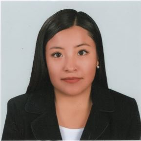

## **ANÁLISIS DE DATOS - VALOR DEL INVENTARIO**

## Análisis del Valor del Inventario de la Empresa de Aceros Galvanizados ACERGAL SRL.

La Empresa de Aceros Galvanizados ACERGAL SRL, desarrolla sus actividades entorno a la producción y comercialización de productos elaborados en base a Aceros Galvanizados, tales como: Calaminas Ensambles, y Perfiles para construcción. Dentro de el Almacén de Productos terminados se cuenta con un stock variado en cuanto cantidades, según cada uno de los item que permite la identificación de los productos, de los cuales se realizara el análisis.

[figure not shown]

## Artículos Científicos

Son artículos cientificos que permiten el apoyo a la realizacion del analisis de los datos del stock en Almacenes de Acergal Srl.

### Modelos y Métodos para la Planificación de la Producción de la Cadena de Suministro bajo Incertidumbre: Una introducción al Estado del Arte.

### Modelo de gestión de inventarios: conteo cíclico por análisis ABC

### Análisis y propuesta de implementación de pronósticos, gestión de inventarios y almacenes en una comercializadora de vidrios y aluminios

## Libro de Apoyo

### **Gestión de inventarios. COML0210**

## Datos del Valor del Inventario

```r
library(readxl)
datos <- read_excel("datos.xlsx")
head(datos[1:5])
```

```
## # A tibble: 6 x 5
##   `Código de Item` Descripción `CANTIDAD ZOFRA` `CANTIDAD NERY` `CANTIDAD CALAC~
##   <chr>            <chr>                  <dbl>           <dbl>            <dbl>
## 1 LGFHO178003000   Lam Galv F~             4694              68             2266
## 2 LGFHO178002450   Lam Galv F~            19113             264             1664
## 3 LGFHO178001800   Lam Galv F~             8547             644             1396
## 4 LGFHO279003000   Lam Galv F~             8347             753              665
## 5 LGFHO279002450   Lam Galv F~             8307             420              832
## 6 LGFHO178002150   Lam Galv F~             5407             360              844
```

```
Donde los datos que se describe son:
  - Código de Ítem
  - Descripción de Producto
  - Cantidad Zofra (Valor de Inventario de Almacenes de Zona Franca El Alto - ZOFRA)
  - Cantidad Nery (Valor de Inventario de Almacenes de Nery El Alto - NERY)
  - Cantidad Calacoto (Valor de Inventario de Almacenes de Zona Calacoto La Paz - CALACOTO)
```

#### DESCRIPCION DEL PRODUCTO

- El analisis se realiza de la cantidad de producto, que en este caso son las Calaminas, producidas a partir del acero galvanizados, ne distintas formas, tales como: Teja American, Teja Española, Teja Andina, Trapezoidal XL, Trapezoidal, Ondulada y Planas.

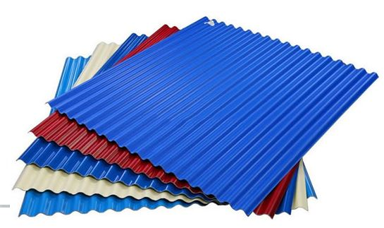

Producto acergal

## Análisis de Datos

```
##  Código de Item     Descripción        CANTIDAD ZOFRA  CANTIDAD NERY
##  Length:90          Length:90          Min.   :    0   Min.   :  -3.0
##  Class :character   Class :character   1st Qu.:  311   1st Qu.: 115.5
##  Mode  :character   Mode  :character   Median :  981   Median : 237.0
##                                        Mean   : 1855   Mean   : 323.2
##                                        3rd Qu.: 2078   3rd Qu.: 423.0
##                                        Max.   :19113   Max.   :1621.0
##  CANTIDAD CALACOTO
##  Min.   :   1.00
##  1st Qu.:  47.75
##  Median : 197.50
##  Mean   : 386.71
##  3rd Qu.: 509.75
##  Max.   :2524.00
```

## Gráficos del Valor del Inventario

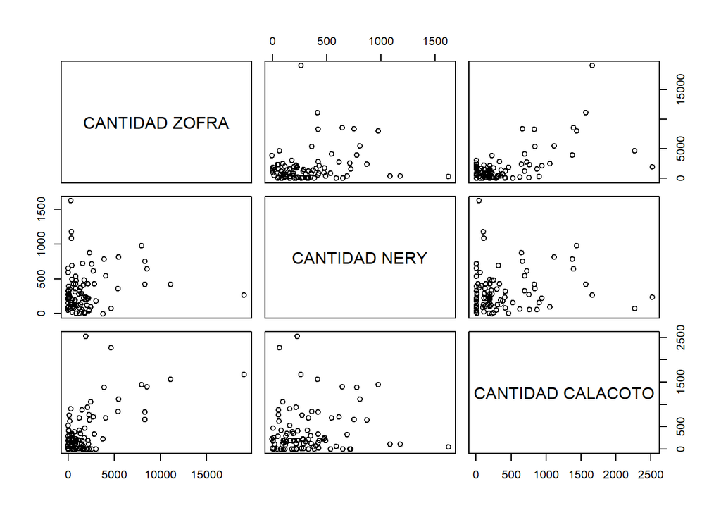

## HISTOGRAMAS

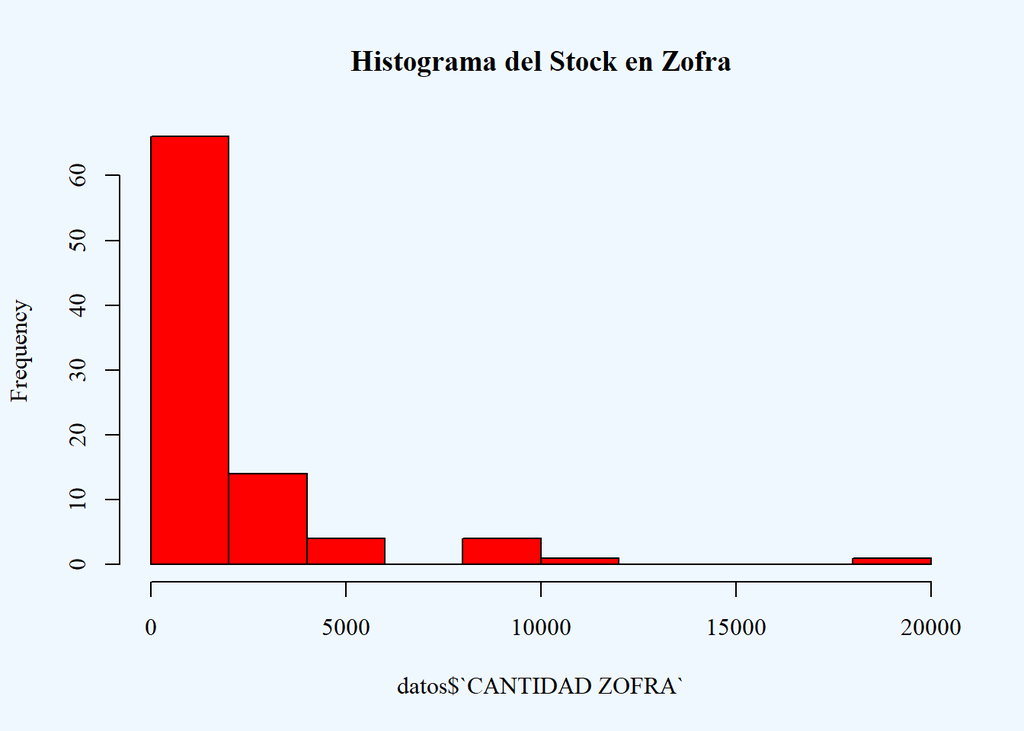

*El histograma refleja el stock que presenta el Almacen de Zofra, y como se puede ver una gran cantidad de items se encuentra entre la cantidad de 0 a 5000 unidades (hojas de calamina), eso debido a que en el mismo lugar se encuentra la Planta de Producción*

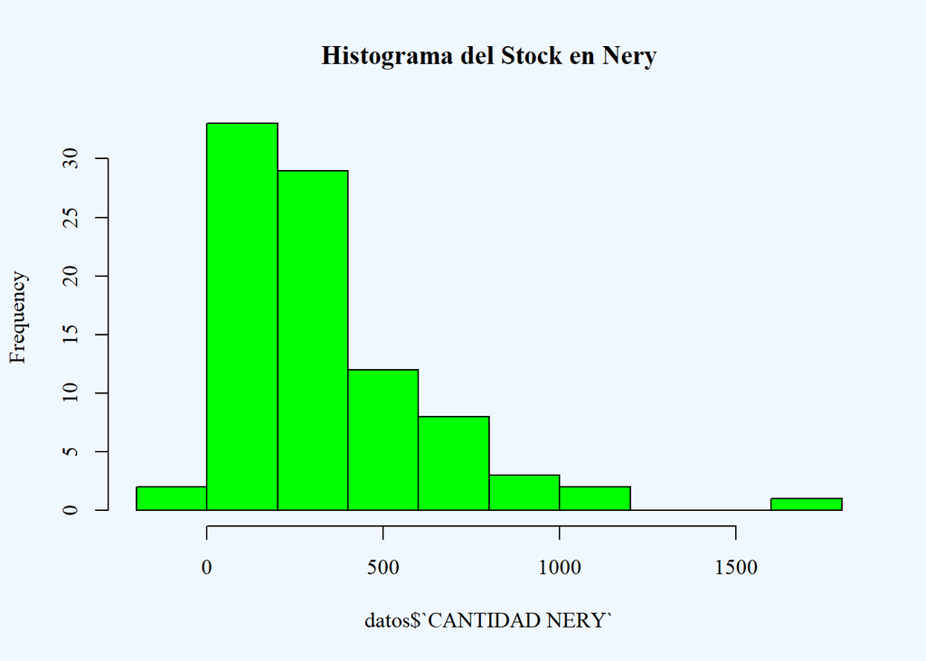

*El histograma refleja el stock que presenta el Almacen de Nery,Unidad Comercializadora y como se puede ver una gran cantidad de items se encuentra entre la cantidad de 0 a 500 unidades (hojas de calamina), observandose tambien que existe valores negativos, eso debido a la falta de actualización de datos en sistema de inventaros por traspaso de material*

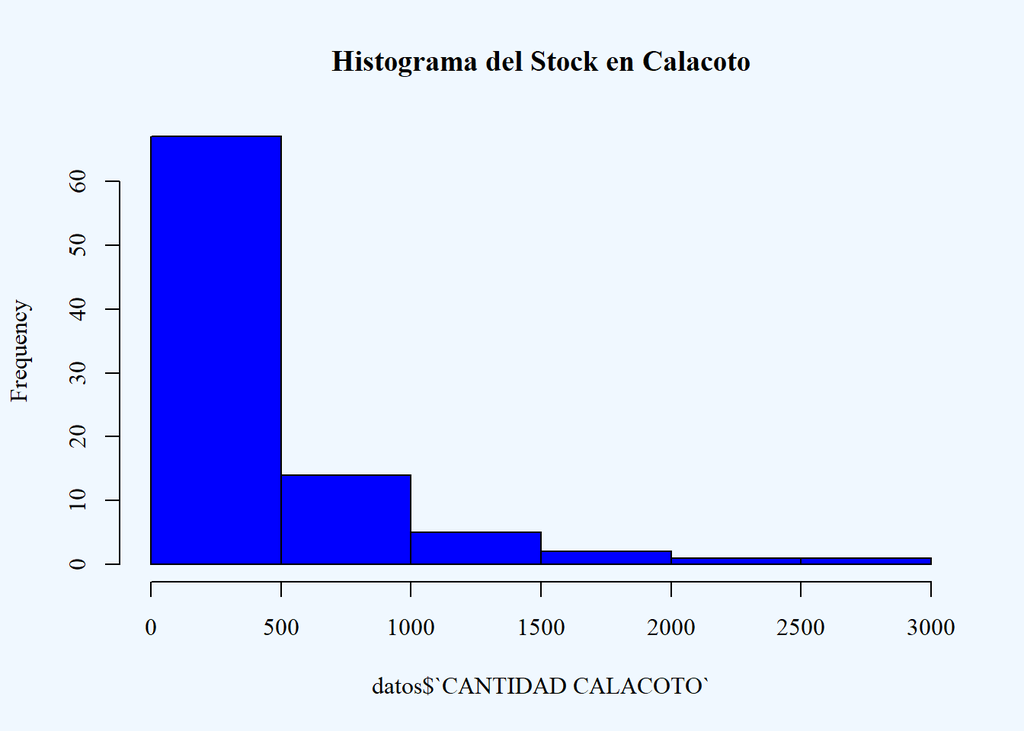

*El histograma refleja el stock que presenta el Almacen de Calacoto,Unidad Comercializadora y como se puede ver una gran cantidad de items se encuentra entre la cantidad de 0 a 500 unidades (hojas de calamina)*

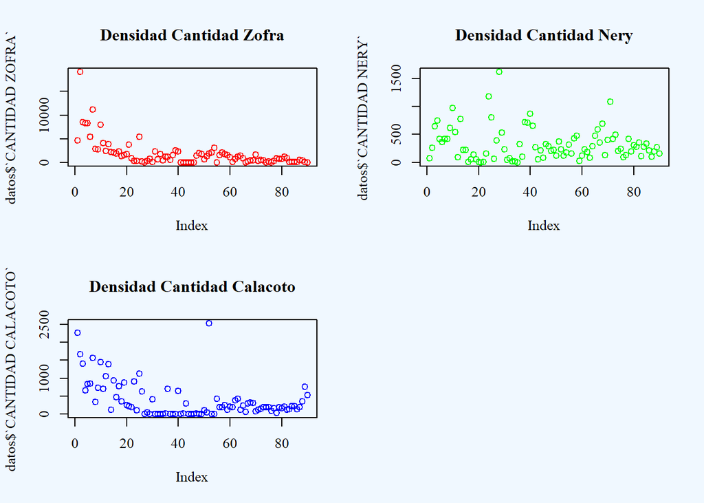

## CUANTILES

[figure not shown]

## DIAGRAMA DE CAJAS

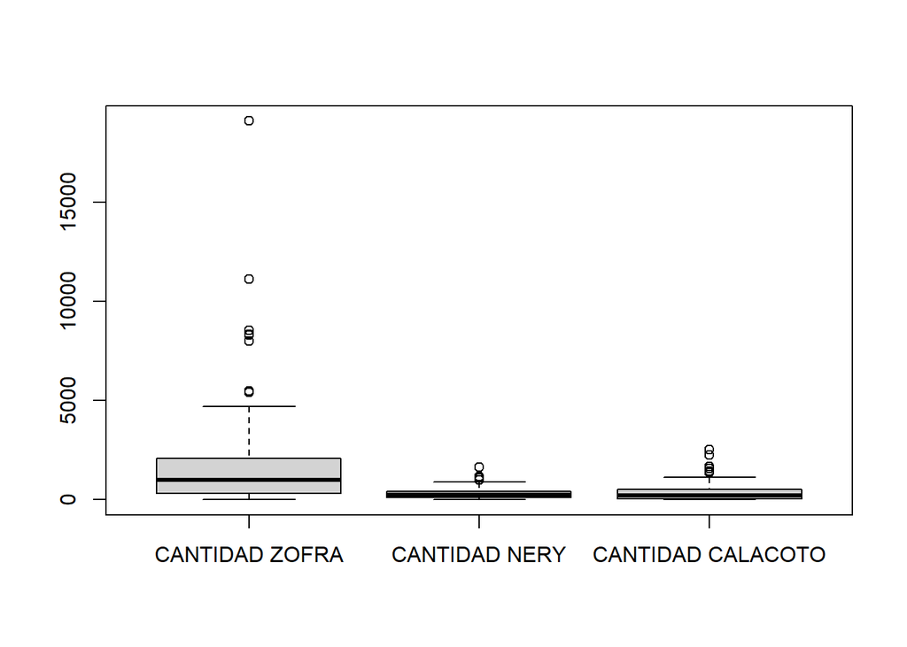

```
##                   CANTIDAD ZOFRA CANTIDAD NERY CANTIDAD CALACOTO
## CANTIDAD ZOFRA         1.0000000    0.16832703        0.60613770
## CANTIDAD NERY          0.1683270    1.00000000        0.08331494
## CANTIDAD CALACOTO      0.6061377    0.08331494        1.00000000
```

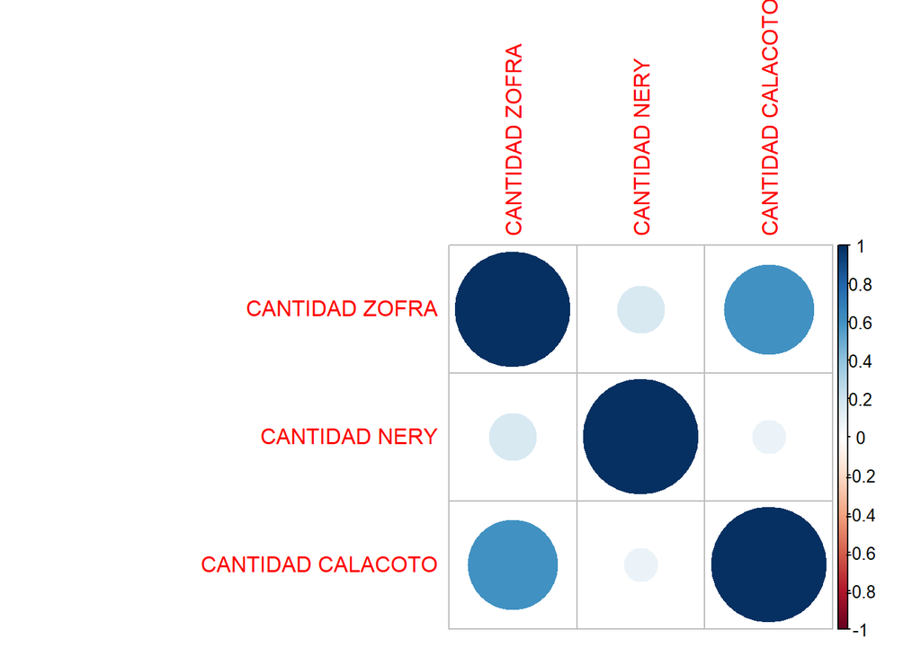

```
## integer(0)
```

*Dentro de las Filas de Datos, no se encuentran valores N/A, valores ausentes*

```
## Standard deviations (1, .., p=1):
## [1] 1
##
## Rotation (n x k) = (1 x 1):
##      PC1
## [1,]   1
```

```
## Importance of components:
##                        PC1
## Standard deviation       1
## Proportion of Variance   1
## Cumulative Proportion    1
```

```
## [1] 1
```

```
## [1] 1
```

```
## [1] 1
```

```
## [1] NA
```

```
## [1] NA
```

```
##      CP1 CP2 CP3
## [1,]   1  NA  NA
```

## REFERENCIAS BIBLIOGRAFICAS

### [Markdown - La guía definitiva en español](https://markdown.es/)

### [RPubs](https://rpubs.com/)